# Encuesta sobre servicios de diagnóstico de laboratorios de micología en Perú

# 10 Antifungal susceptibility testing

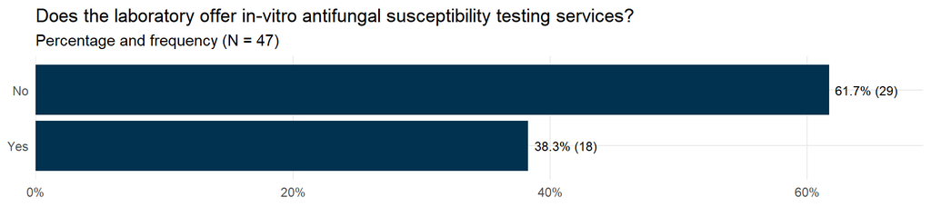

## 10.1 Does the laboratory perform the antifungal susceptibility tests or are they sent to an external laboratory?

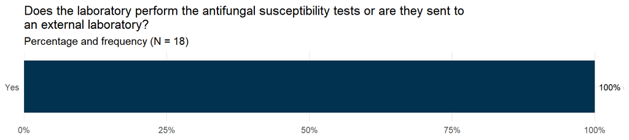

## 10.2 What types of fungi are antifungal susceptibility tests available for?

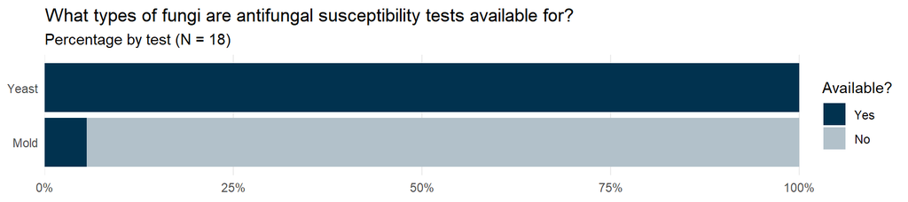

# 11 Serological tests

## 11.1 Are antibody tests against fungi (*Aspergillus sp.*, *Histoplasma capsulatum*, *Paracoccidioides brasiliensis*) available in your laboratory?

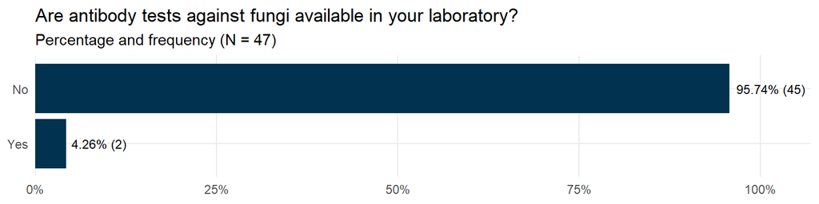

## 11.2 Are antibody tests against fungi available in another laboratory in your hospital?

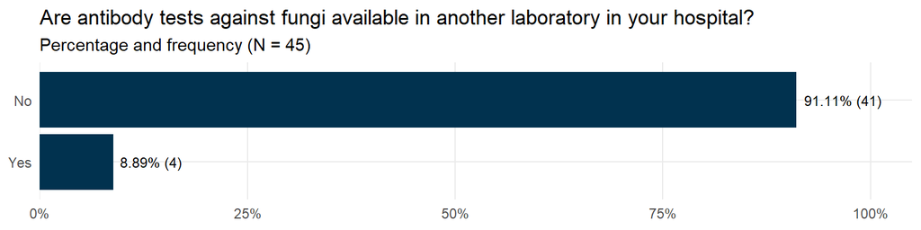

## 11.3 Are the tests for the detection of antibodies against fungi sent to an external laboratory?

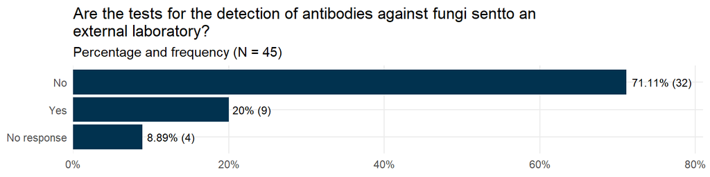

## 11.4 Are *Cryptococcus* antigen detection tests available in your laboratory?

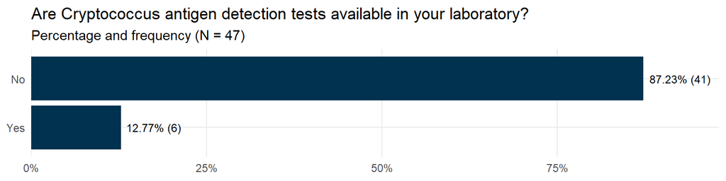

## 11.5 Are *Cryptococcus* antigen tests available at another hospital lab?

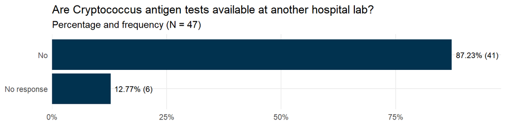

## 11.6 Are Cryptococcus antigen tests sent to an external laboratory?

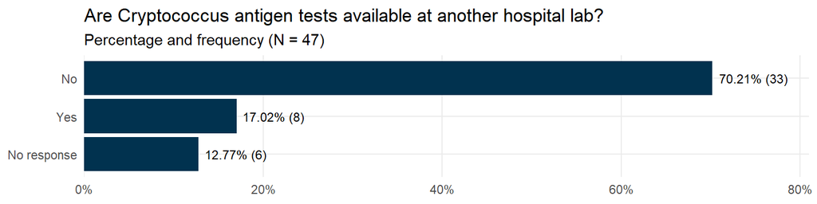

## 11.7 Are antigen detection tests for Cryptococcus available in your laboratory?

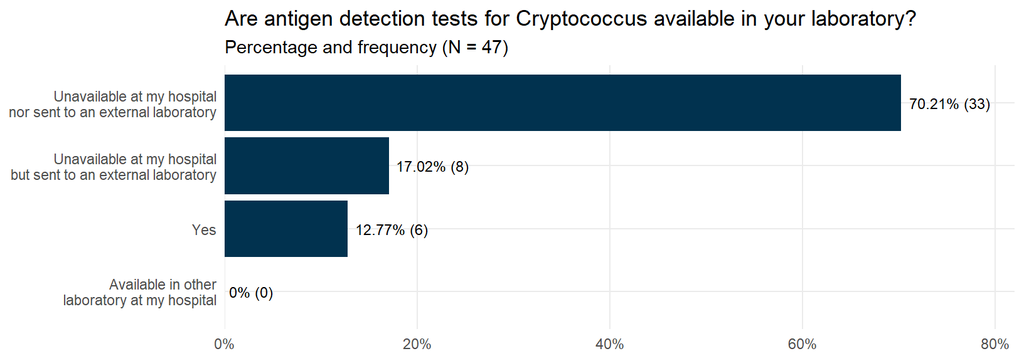

## 11.8 Which antigen detection tests for Cryptococcus are available in your laboratory or hospital?

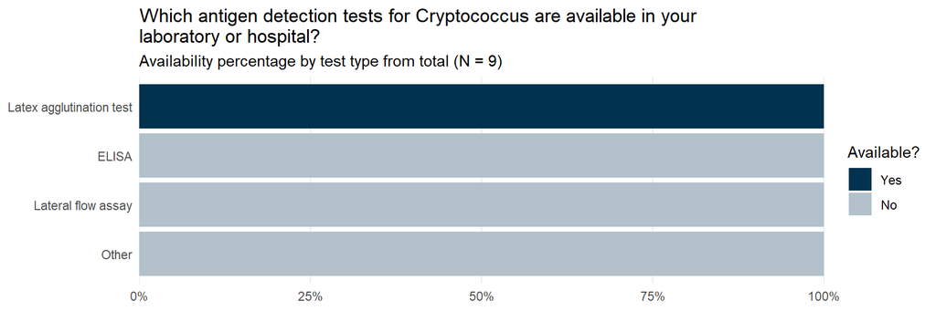

## 11.9 Are antigen detection tests for Histoplasma capsulatum available in your laboratory?

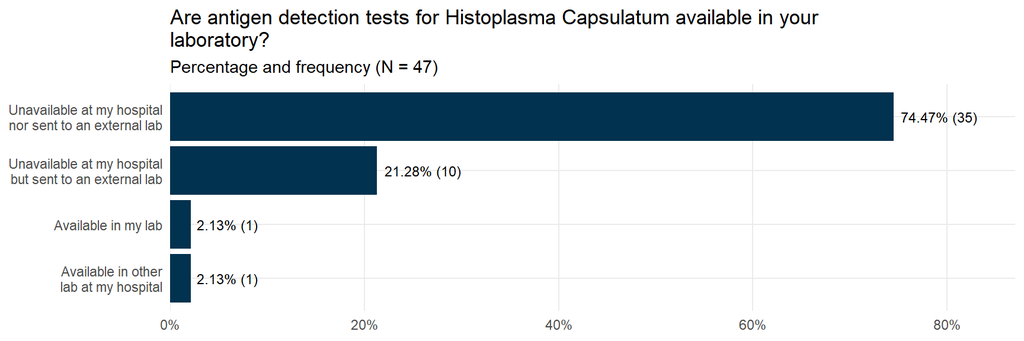

## 11.10 Are antigen detection tests for Aspergillus sp. available in your laboratory?

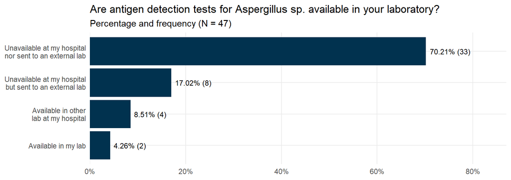

# 12 Molecular diagnosis

## 12.1 Are PCR tests for the diagnosis of fungi available in your laboratory/hospital?

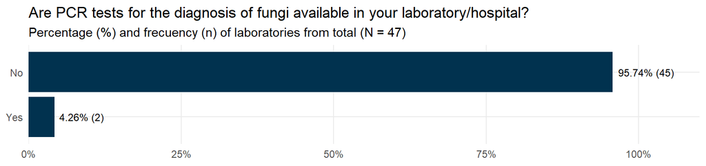

## 12.2 Available PCR tests for the diagnosis of fungi

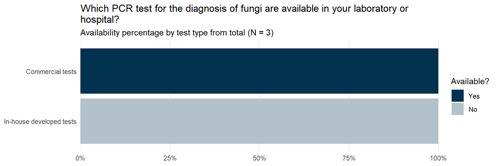

# 13 Other capacities

## 13.1 Available antifungals for the treatment of patients

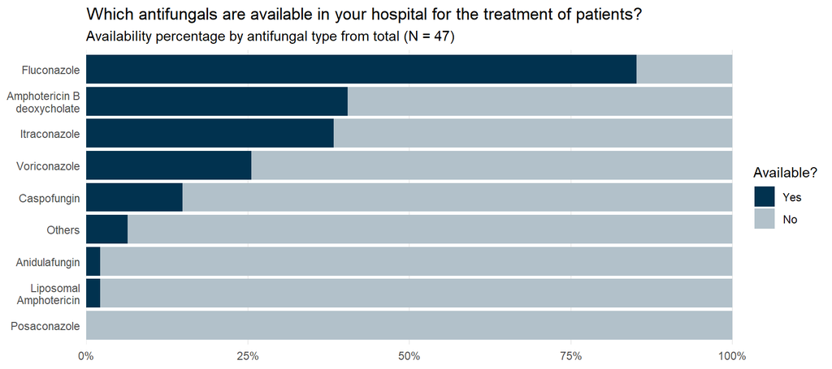